# Structural and Lexical Analysis of Synthetic Multi-Agent Conversations

2026-01-20

## Introduzione

La generazione di dati sintetici è sempre più rilevante per l’ecosistema degli LLM, soprattutto quando i dati reali non sono condivisibili per motivi di privacy. In questo contesto, i **sistemi multi-agente (MAS)** permettono di generare conversazioni tra AIs che simulano interazioni umane mantenendo un buon livello di diversificazione.

In questa presentazione analizziamo **SOC (Synthetic Online Conversations)**, generato a partire da *Personas* ed *Experiences* assegnate agli agenti per forzare interazioni variate.

**Domande di analisi:**

- **Q1 (Lexical Diversity):** la diversità lessicale supera benchmark umani?
- **Q2 (Statistical Bias):** emerge un “bias sintetico” rispetto a un corpus standard?
- **Q3 (Network Structure):** i concetti semantici mostrano una struttura coerente?

## Metodologia (in breve)

L’analisi combina **text mining** (profiling lessicale, keyness) e **network science** (reti semantiche via co-occorrenze).

- `koRpus`: calcolo **MTLD**
- `quanteda`: frequenze, **keyness**, **FCM** (Feature Co-occurrence Matrix)
- Confronti: benchmark umani (es. DailyDialog) e corpus di inglese generale (file `en_texts_dynamic.txt`)

## Q1 — Diversità lessicale: logica MTLD

Per misurare la ricchezza del vocabolario usiamo **MTLD**, più stabile della TTR su testi di lunghezza variabile.

```r
# Helper per MTLD con koRpus
get_mtld_korpus <- function(x) {
  if (is.na(x) || nchar(x) == 0) return(NA)
  tryCatch({
    tagged <- tokenize(x, lang = "en", format = "obj")
    MTLD(tagged)@MTLD$MTLD
  }, error = function(e) NA)
}
```

Nota: il calcolo MTLD riga-per-riga è costoso su dataset grandi; nelle prossime slide riportiamo i risultati pre-calcolati (coerenti col report).

## Q1 — Parole rare (hapax legomena)

Prima dell’indice globale, osserviamo quante parole appaiono una sola volta: sono un segnale (grezzo) di varietà e “creatività” lessicale.

```r
chat_tokens <- quanteda::tokens(
  chat_corpus,
  remove_punct = TRUE,
  remove_symbols = TRUE,
  remove_numbers = TRUE
)

chat_dfm <- dfm(chat_tokens)

freq_stats <- textstat_frequency(chat_dfm)
rare_words <- freq_stats %>% filter(frequency == 1)

num_rare <- nrow(rare_words)
examples_rare <- paste(head(rare_words$feature, 8), collapse = ", ")

cat("Numero di hapax legomena:", num_rare, "\n")
```

```
## Numero di hapax legomena: 10809
```

```r
cat("Esempi:", examples_rare, "\n")
```

```
## Esempi: stress-checking, hcpcs, backstreets, thiefs, regrettable, prequel, outpatient, non-billable
```

## Q1 — Risultati MTLD (con benchmark)

```r
# data$mtld_score <- sapply(data$text, get_mtld_korpus)
# observed_mtld <- mean(data$mtld_score, na.rm = TRUE)

# Per ragioni di efficienza, usiamo il risultato pre-calcolato nel report
observed_mtld <- 159.81
human_benchmark <- 53.44     # DailyDialog
old_synth_low <- 85          # ~ConvoGen (indicativo)
old_synth_high <- 129

results_df <- data.frame(
  Source = c("SOC (Ours)", "Human (DailyDialog)", "Synthetic (ConvoGen)"),
  MTLD_Score = c(observed_mtld, human_benchmark, old_synth_high)
)

results_df
```

```
##                 Source MTLD_Score
## 1           SOC (Ours)     159.81
## 2  Human (DailyDialog)      53.44
## 3 Synthetic (ConvoGen)     129.00
```

**Risultato principale:** SOC raggiunge **MTLD = 159.81**, superiore sia alla baseline umana (DailyDialog \(\approx 53.44\)) sia alle baseline sintetiche precedenti (circa \(85\text{–}129\)).

**Interpretazione:** la combinazione di *Seed Persona* e *Seed Experiences* “forza” l’LLM a coprire un lessico molto più ampio del tipico chatbot. **Tuttavia**, un valore così alto può risultare anche “innaturale”: gli agenti tendono a toccare molti temi rapidamente (effetto conversazione “rushed”), aumentando artificiosamente la varietà.

## Q2 — Keyness: preparazione confronto

Per identificare bias (“accento sintetico”), confrontiamo le chat con un corpus di inglese generale e calcoliamo la **keyness** (Chi2).

```r
gen_path <- "data/raw/en_texts_dynamic.txt"

gen_lines <- readLines(gen_path, warn = FALSE)
gen_data <- data.frame(text = gen_lines, stringsAsFactors = FALSE)

corpus_chat <- chat_corpus
docvars(corpus_chat, "Source") <- "Conversational"

corpus_gen <- corpus(gen_data, text_field = "text")
docvars(corpus_gen, "Source") <- "English_Corpus"
docnames(corpus_gen) <- paste0("gen_", seq_len(ndoc(corpus_gen)))

master_corpus <- corpus_chat + corpus_gen

master_tokens <- quanteda::tokens(
master_corpus,
remove_punct = TRUE,
remove_symbols = TRUE,
remove_numbers = TRUE
)

master_dfm <- dfm(master_tokens)
dfm_grouped <- dfm_group(master_dfm, groups = docvars(master_corpus, "Source"))
```

## Q2 — Keyness: risultati e lettura

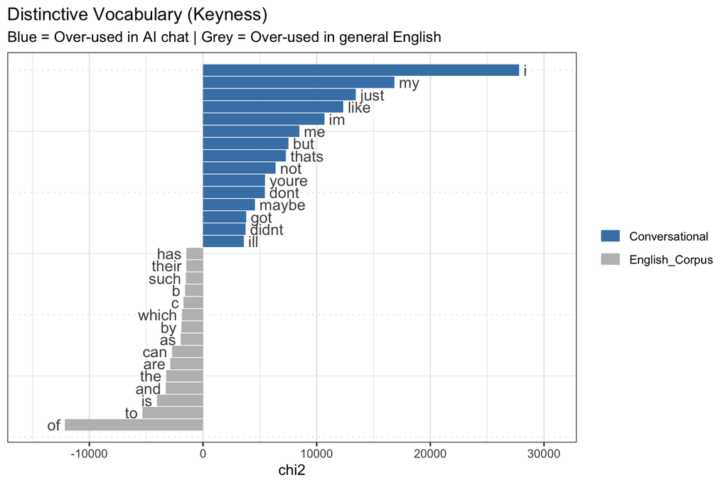

```r
keyness_stat <- textstat_keyness(dfm_grouped, target = "Conversational")

textplot_keyness(keyness_stat, n = 15, color = c("steelblue", "grey")) +
labs(
    title = "Distinctive Vocabulary (Keyness)",
    subtitle = "Blue = Over-used in AI chat | Grey = Over-used in general English"
)
```

**Risultato principale:** emerge un forte **bias auto-referenziale**: termini come *I, my, just, like, Im* risultano sovra-rappresentati (Chi2 molto elevati, \(> 10{,}000\)).

**Interpretazione:** il bias è in parte **atteso** perché gli agenti sono progettati per parlare in prima persona; il punto critico è la *sovra*-presenza, che può rendere lo stile ripetitivo o “egocentrico”. In parallelo, l’assenza di termini tematici troppo specifici nella top-list suggerisce che il dataset non è fissato su un singolo argomento, coerentemente con l’alta MTLD.

## Q3 — Network semantica: preparazione FCM

Costruiamo una rete tramite **Feature Co-occurrence Matrix (FCM)** (finestra = 5). Rimuoviamo stopword e filler per far emergere i temi.

```r
custom_stopwords <- c(
  stopwords("en"),
  "just", "like", "im", "thats", "dont", "can", "cant",
  "one", "also", "really", "get", "go", "know", "think",
  "well", "see", "good", "got", "ve", "re", "ll", "ill",
  "said", "didnt", "back", "us", "yeah", "okay", "yes", "oh",
  "right", "sure", "maybe", "youre", "going", "want", "hes",
  "theyre", "isnt", "ive", "would", "could", "much"
)

tokens_net <- quanteda::tokens(chat_corpus, remove_punct = TRUE, remove_numbers = TRUE) %>%
  tokens_tolower() %>%
  tokens_remove(custom_stopwords)

chat_fcm <- fcm(tokens_net, context = "window", window = 5, tri = FALSE)

top_feats <- names(topfeatures(dfm(tokens_net), 50))
chat_fcm_select <- fcm_select(chat_fcm, pattern = top_feats)
```

## Q3 — Network: visualizzazione

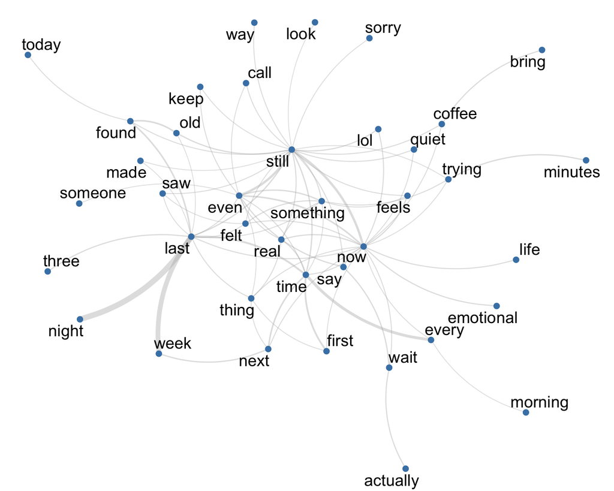

```r
textplot_network(
  chat_fcm_select,
  min_freq = 50,
  edge_alpha = 0.4,
  edge_size = 2,
  edge_color = "grey70",
  vertex_color = "steelblue",
  vertex_labelcolor = "black",
  vertex_labelsize = 5
)
```

**Risultato principale:** la rete mostra comunità concettuali riconoscibili. In particolare emergono cluster legati al **tempo** (es. *last, night, week*) e alle **emozioni** (es. *sorry, felt, emotional*), coerenti con la natura “empatica” delle *Seed Experiences*.

## Conclusioni e next steps

La pipeline MAS produce un dataset **iper-diverso** ma con segnali stilistici riconoscibili.

- **Q1:** MTLD \(= 159.81\) → diversità lessicale molto superiore alle baseline; possibile effetto collaterale di conversazioni “rushed”
- **Q2:** keyness → bias auto-referenziale (prima persona) atteso ma potenzialmente eccessivo
- **Q3:** rete semantica → struttura coerente con temi temporali ed emotivi, suggerendo contenuto non casuale

**Prossimi passi:**

- Rendere le conversazioni più naturali “rallentando” il topic switching (vincoli/metriche di fluidità)
- Ridurre l’auto-referenzialità con prompt/ruoli più stringenti e controlli post-processing
- Aggiungere una valutazione qualitativa (campionamento manuale) per distinguere diversità utile vs. diversità artificiale